# Time Series Analysis of Copper Prices

Daniel Hopp

4 January 2019

## Exposition of the Problem

The goal of this analysis is to get a better sense of how copper prices behave, with the ultimate goal of being able to identify, with a reasonable degree of certainty, if a day’s price is the lowest that can be expected over a 4 week period. Of course the price of copper is dependent on many different factors, including prices/indicators of other commodities, inventory levels, regulatory announcements, geopolitical conditions in source countries, and indicators of downstream industries. However for simplicity and ease of use/interpretation, this analysis will stick with only copper’s past prices as indicators of its future direction.

### Data

Historical data on copper prices was obtained from: https://www.macrotrends.net/1476/copper-prices-historical-chart-data, which has daily copper prices (USD/pound) starting from 2 July 1959. Though it uses different units than the London Metal Exchange (USD/pound instead of USD/Ton), the shape of the historical data is the same. The source makes no mention of inflation, but we will assume prices are in constant dollars. A simple plot of the raw data will give us an initial idea of how copper prices have developed over time. Recessions are also shaded to give an indication of copper prices’ relation to overall economic performance.

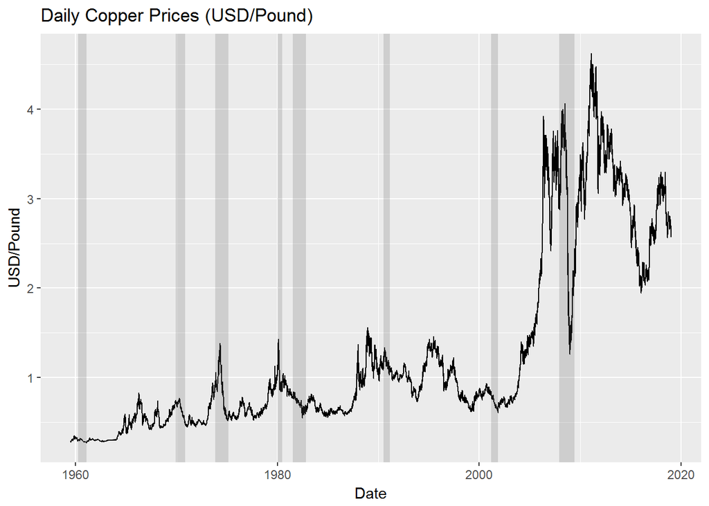

```r
library(ggplot2)
library(tseries)
library(lmtest)
library(astsa)

data <- read.csv('hist copper.csv')

#converting date to datetime data type
data$date <- as.Date(data$date)

#data on recessions for plot
recessions.df = read.table(textConnection(
"Peak, Trough
1960-04-01, 1961-02-01
1969-12-01, 1970-11-01
1973-11-01, 1975-03-01
1980-01-01, 1980-07-01
1981-07-01, 1982-11-01
1990-07-01, 1991-03-01
2001-03-01, 2001-11-01
2007-12-01, 2009-06-01"), sep=',',
colClasses=c('Date', 'Date'), header=TRUE)
recessions.trim = subset(recessions.df, Peak >= min(data$date))

#function for simple line plot
line_plot <- function(data, date, value, title, xlab, ylab){
  plot <- ggplot(data = data, aes(x = date, y = value, group = 1)) +
  geom_line() +
  ggtitle(title) +
  xlab(xlab) +
  ylab(ylab)
  plot
}

line_plot(data, date, value, "Daily Copper Prices (USD/Pound)", "Date", "USD/Pound") +
  geom_rect(data=recessions.trim, aes(xmin=Peak, xmax=Trough, ymin=-Inf, ymax=+Inf), alpha=0.2, inherit.aes = FALSE)
```

#### Interpretation

We see that on a macro level, copper prices don’t seem to follow any readily discernible pattern, beyond the fact that they go down (maybe with some delay) during recessions, so some quantitative time series analyses will need to be done. But first, to get a better look at how the prices behave on a smaller time scale, we will look at the plot of the last 6 months.

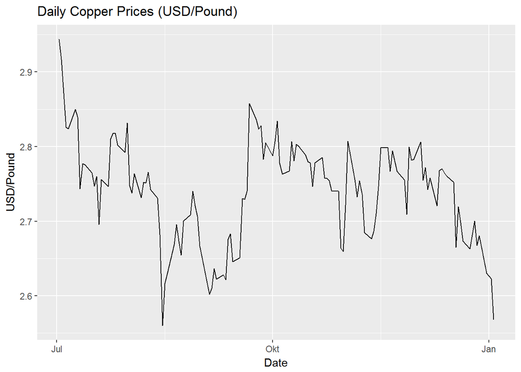

```r
line_plot(data[data$date >= "2018-07-01",], date, value, "Daily Copper Prices (USD/Pound)", "Date", "USD/Pound")
```

#### Interpretation

On a micro level, the series seems to have a certain degree of mean correction, however a random walk still looks possible. To get a better idea of the time series’ nature, more analyses will need to be performed.

### Copper Prices by Day of Week

Before estimating a time series model, we will look at the development of copper prices by day of week. The hypothesis is that prices may display a weekly seasonality and thus there is an ideal day of the week to buy. To examine this we’ll first look very generally at mean prices by day of week.

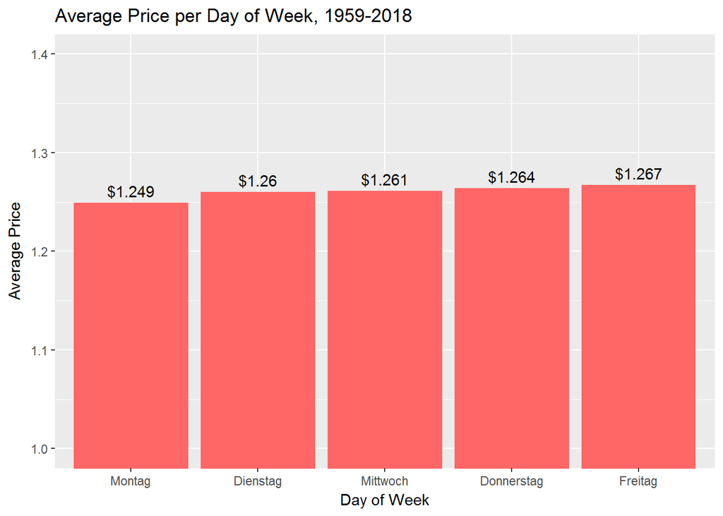

```r
#get day of week
data$dow <- weekdays(data$date)
monday <- data[2,"dow"]
tuesday <- data[3,"dow"]
wednesday <- data[4,"dow"]
thursday <- data[5,"dow"]
friday <- data[6,"dow"]

library(scales)
#bar graph for all time
all <- data[data$date >= '1949-01-01',]
bar_data <- aggregate(all$value, list(all$dow), mean)
bar_data$Group.1 <- factor(bar_data$Group.1, levels = c(monday, tuesday, wednesday, thursday, friday))
ggplot(data = bar_data, aes(x = Group.1, y = x)) +
  geom_col(fill = "#FF6666") +
  geom_text(aes(label = paste("$", round(bar_data$x, 3), sep="")), vjust = -0.5) +
  scale_y_continuous(limits=c(1,1.4),oob = rescale_none) +
  ggtitle("Average Price per Day of Week, 1959-2018") +
  xlab("Day of Week") +
  ylab("Average Price")
```

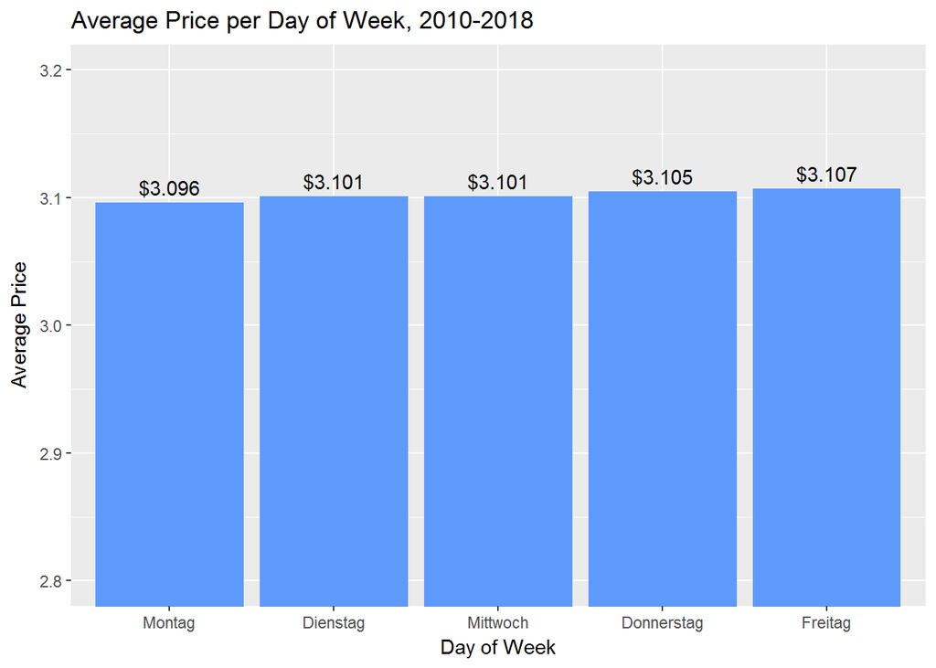

```r
#bar graph for 2010-2018
all <- data[data$date >= '2010-01-01',]
bar_data <- aggregate(all$value, list(all$dow), mean)
bar_data$Group.1 <- factor(bar_data$Group.1, levels = c(monday, tuesday, wednesday, thursday, friday))
ggplot(data = bar_data, aes(x = Group.1, y = x)) +
  geom_col(fill = "#5d9afc") +
  geom_text(aes(label = paste("$", round(bar_data$x, 3), sep="")), vjust = -0.5) +
  scale_y_continuous(limits=c(2.8,3.2),oob = rescale_none) +
  ggtitle("Average Price per Day of Week, 2010-2018") +
  xlab("Day of Week") +
  ylab("Average Price")
```

#### Interpretation

Over the whole data set we see a slight trend of increasing prices during the course of the week, with cheapest prices on Monday (by about only 1 or 2 cents) and most expensive on Friday To make sure this wasn’t a time dependent anomaly, the same graph was produced for only 2010-2018. We see the same trend but weaker. Despite the existance of this trend, the evidence is not strong enough to be able to make a blanket recommendation for simply buying earlier in the week. So we move on to the time series analysis.

### Time Series Model

We will now transform the data to obtain a stationary series. We already saw from our initial plot that the raw data is not a stationary time series, as there are clear trends. Our initial impression can be verified using an Augmented Dickey-Fuller Test for a unit root, obtaining a p-value of 0.22. This is not sufficient to reject the null hypothesis of a non-stationary series, so first we will try first differencing to see if we then obtain a stationary process. The result of that transformation has a Dickey-Fuller p-value of 0.01, indicating stationarity and is plotted below.

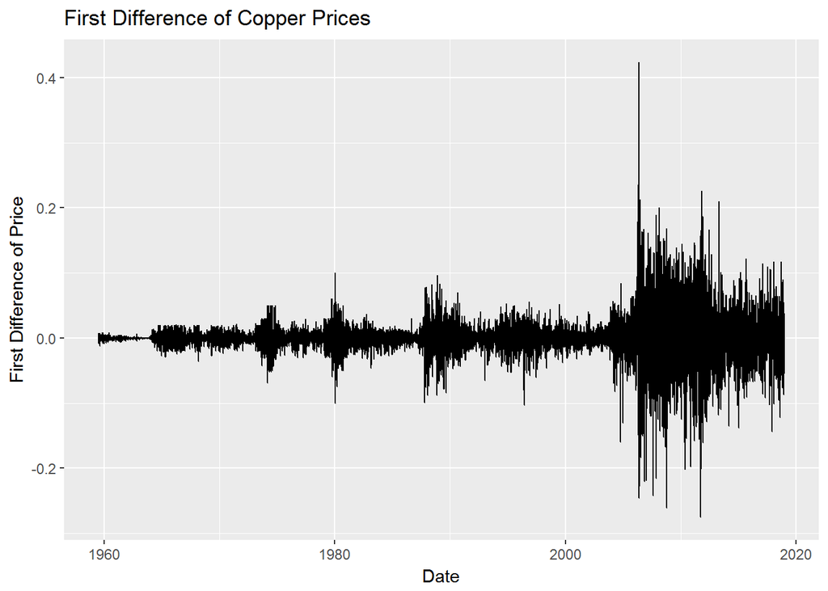

```r
ggplot(data = data, aes(x = date, y = c(0, diff(data$value)))) +
  geom_line() +
  ggtitle("First Difference of Copper Prices") +
  xlab("Date") +
  ylab("First Difference of Price")
```

#### Interpretation

Any trends are gone, however we see a high degree of heteroskedasticity even without any tests, with variance increasing with time. This tells us we need to log transform the series, then first difference, which is plotted below.

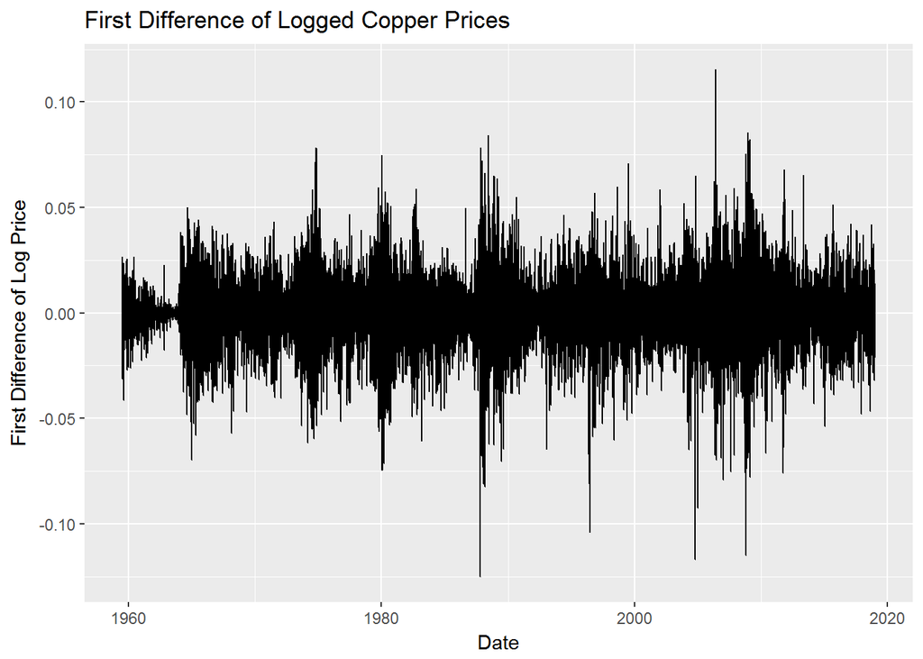

```r
ggplot(data = data, aes(x = date, y = c(0, diff(log(data$value))))) +
  geom_line() +
  ggtitle("First Difference of Logged Copper Prices") +
  xlab("Date") +
  ylab("First Difference of Log Price")
```

#### Interpretation

To the eye it appears that the series is no longer heteroskedastic, but that can be verified with a test. The Goldfeld-Quandt test for heteroskedasticity obtains a p-value of 0.06, which is >.05 and allows us to accept the null hypothesis that variance does not change between segments, and thus our series is homoskedastic. Now we can use R’s SARIMA function to estimate a time series model for the data.

```r
library(forecast)

#create time series data
ts <- ts(data = diff(log(data$value)), start = c(1959, 125), end = c(2019, 1), frequency = 250)

model <- auto.arima(ts)
model
```

```
## Series: ts
## ARIMA(0,0,0) with zero mean
##
## sigma^2 estimated as 0.0002619:  log likelihood=40239.36
## AIC=-80476.72   AICc=-80476.72   BIC=-80469.12
```

#### Interpretion

The interpretation of the auto.arima output is as follows: the optimal model, based on both AIC and BIC, is an ARIMA(0,0,0) with a mean of 0, meaning the best prediction of log differences in the time series is simply 0. Transforming back (i.e. taking away the first difference and unlogging) to our original variable (copper prices), translates to a random walk with no drift. That is to say that the best estimate of tomorrow’s copper price is simply today’s copper price. This corroborates Wets findings in his 2012 paper *(Wets and Rios (2012))*, available here: https://www.math.ucdavis.edu/~rjbw/mypage/Mathematics\_of\_Finance_files/WtsR13.pdf. Their logic was that though economically speaking copper prices should be mean reverting due to supply and demand, in reality supply responds so slowly to prices (due to long-term contracts, the excessive time involved to start up or shut down a copper mine) that on a shorter scale mean reversion is negligable. They have similar findings for the explanation of a lack of drift parameter in the random walk. On long term horizons there is most likely a slight positive drift parameter, but on micro scales it is effectively 0.

### Implications, Below Rolling Mean Algorithm

Unfortunately this tells us that we cannot glean too much information from the series itself, and that instead copper prices are driven more by external factors like market news, etc. However since the ultimate goal is not to predict copper prices, but rather to select the lowest price in a period of four weeks, there is still further analysis that can be done. What follows is an analysis that will evaluate a day’s price compared to the mean price of the past x number of days. The idea is to identify abnormally low priced days, with the two parameters being the number of previous days to include in the mean, and the threshold for considering a day likely to be the lowest, or among the lowest, in a 4 week period (e.g. 15% below mean of last 30 days, 20% below mean of last 15 days, etc.). The models will then be evaluated on two metrics, percentage of time they were correct, i.e. they were the lowest in the four week period, and mean difference from the real lowest. The result of the analysis will be a simple, digestible recommendation in the form of: “If today’s copper price is x% below the mean of the past x days, copper should be purchased today to have a high chance of being the lowest in a four week period”. Additionally the method will have a digestible justification in the form of: “This method correctly identifies the lowest price in a four week period x% of the time, and when it is wrong it averages x dollars more than the actual lowest price in the period.”

```r
#definition of function for rolling mean model
rolling_mean <- function(x_days, threshold){

  #initializing variables for evaluation
  correct <- 0
  mean_sq <- 0
  mean <- 0
  total <- length(seq(126, nrow(data) - 20, 20))
  misses <- 0
  mon_count <- 0
  tue_count <- 0
  wed_count <- 0
  thu_count <- 0
  fri_count <- 0

  #126 is first monday in 1960, -20 because need four weeks forward data to evaluate, by 20 because going over 4 week periods
  for(y in seq(126, nrow(data) - 20, 20)){
    temp <- data$value[y:(y+19)]
    for(i in 1:length(temp)){
      value <- temp[i]
      #y + i - x_days - 2 is how many days back depending on parameter, trailing goes up as i goes up, y + i - 2 is day before the days price
      last_x_mean <- mean(data$value[(y + i - x_days - 2):(y + i - 2)])

      #if the value is lower than the threshold take that value and break
      if(value/last_x_mean-1 <= threshold * -1){
        final_value <- value
        break
      #if the threshold is never reached, simply take the last value in the 4 week period. This is the risk you take to see if you get a lower price
      }else if(i == length(temp)){
        final_value <- value
        #miss (i.e. had to take the last day because threshold never reached)
        misses <- misses + 1
      }
    }

    #binary evaluation
    if(final_value <= min(temp)){
      correct <- correct + 1
    }
    #mean square evaluation, *100 for interpretability
    mean_sq <- mean_sq + ((value - min(temp)) * 100)^2
    #mean evaluation
    mean <- mean + abs(value - min(temp))
    #day of week stats
    dow_count <- data[y:(y+19),]
    day_lowest <- dow_count[dow_count$value == min(temp),"dow"]
    if(day_lowest == monday){
      mon_count <- mon_count + 1
    }else if(day_lowest == tuesday){
      tue_count <- tue_count + 1
    }else if(day_lowest == wednesday){
      wed_count <- wed_count + 1
    }else if(day_lowest == thursday){
      thu_count <- thu_count + 1
    }else if(day_lowest == friday){
      fri_count <- fri_count + 1
    }
  }

  #what the function returns
  return(
    list(
      "x_days" = x_days,
      "threshold" = threshold,
      "perc_correct" = correct / total,
      "mean_sq_error" = mean_sq / total,
      "mean_error" = mean / total,
      "perc_miss" = misses / total,
      "dow_count" = c(mon_count / total, tue_count / total, wed_count / total, thu_count / total, fri_count / total)
    )
  )
}

#best parameter search
days <- seq(10,100)
threshold <- seq(.01, .5, .01)
final_result <- data.frame(
                 days=integer(),
                 threshold=double(),
                 perc_correct=double(),
                 mean_sq_error=double(),
                 mean_error=double(),
                 perc_miss=double(),
                 stringsAsFactors=FALSE)

#only run to find best parameters
# for(i in days){
#   for(j in threshold){
#     result <- rolling_mean(i, j)
#     final_result <- rbind(final_result, data.frame("days" = result$x_days, "threshold" = result$threshold, "perc_correct" = result$perc_correct, "mean_sq_error" = result$mean_sq_error, "mean_error" = result$mean_error, "perc_miss" = result$perc_miss))
#   }
#   print(i)
# }

#best models, got from above loop then hard coded
#best according to perc_correct
best_perc <- rolling_mean(31, .03)
best_mean_sq <- rolling_mean(13, .1)
best_mean <- rolling_mean(27, .03)
```

#### Below Rolling Mean Algorithm Results

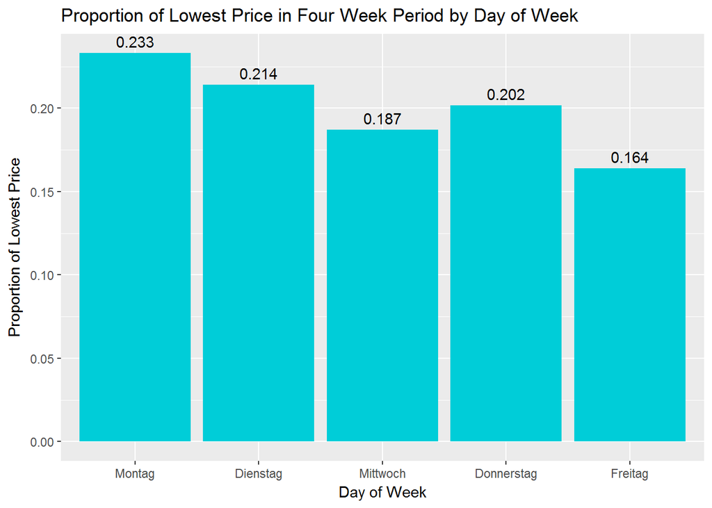

```r
final_dow_plot <- data.frame(dow = c(monday, tuesday, wednesday, thursday, friday), count = best_mean$dow_count)
final_dow_plot$dow <- factor(final_dow_plot$dow, levels = c(monday, tuesday, wednesday, thursday, friday))
ggplot(data = final_dow_plot, aes(x = dow, y = count)) +
  geom_col(fill = "#00cdd8") +
  geom_text(aes(label = paste(round(final_dow_plot$count, 3), sep="")), vjust = -0.5) +
  ggtitle("Proportion of Lowest Price in Four Week Period by Day of Week") +
  xlab("Day of Week") +
  ylab("Proportion of Lowest Price")
```

We can see a trend that mirrors that of average prices by day of week, with Monday most often having the lowest prices, and Friday least often.

### Closing Thoughts and Recommendations

Based on the findings and historical data here, the ideal method of choosing the lowest copper price in a four week period would be to choose a price on a given day if it is 3% below the mean price of the past 27 days. Additionally, the historical data show that this lowest price is most likely to come on a Monday. Combining this analytical approach with market research and heuristics can potentially provide a much stronger purchasing methodology than the two alone.